# Real Estate

First Crown Data Analytics

2024-04-14

### Be sure we have the neccesary packages installed/loaded

```r
# Load all the required packages
library(tidyverse)
library(plm)
library(glmnet)
library(gridExtra)
```

```r
library(tidyr)
library(dplyr)
library(ggplot2)
library(reshape2)
library(car)
```

# Brief explaination of the libraries

tidyverse: The tidyverse is a collection of R packages that work harmoniously together. It shares common data representations and API design. When you load the tidyverse package, it conveniently installs and loads several core packages in one command. Here’s what you get: ggplot2: A powerful system for creating graphics based on the principles of The Grammar of Graphics. It allows you to map variables to aesthetics and specify graphical primitives. dplyr: Essential for data manipulation. It provides functions like filter(), mutate(), and summarize() for efficient data wrangling. tidyr: Helps tidy up your data by reshaping it into a consistent format. Functions like gather() and spread() are commonly used. readr: Simplifies data import from various formats (CSV, Excel, etc.). purrr: Enables functional programming, making it easier to work with lists and vectors. tibble: A modern reimagining of data frames, offering improved printing and other features. stringr: Useful for working with strings. forcats: Deals with factors (categorical variables). lubridate: Handles date and time data.

plm: The plm package stands for “panel linear models.” It’s designed for analyzing panel data (cross-sectional and time-series data combined). You can estimate fixed effects, random effects, and other panel regression models using this package. glmnet: This package implements the elastic net regularization method for fitting generalized linear models. It’s particularly useful for high-dimensional data where you want to select relevant predictors while avoiding overfitting. gridExtra: Provides tools for arranging multiple plots on a single page. You can create custom layouts for your visualizations. reshape2: Helps reshape data from wide to long format and vice versa. Useful for data tidying and visualization. car: The car package contains functions for regression diagnostics, model comparison, and other statistical tasks. It’s especially handy for checking assumptions and assessing model fit.

### Load data

```r
library(readr)
property_database_final <- read_csv("property_database_final.csv")
head(property_database_final)
```

```
## # A tibble: 6 × 53
##      ID PROPERTY_I RESULT_COU OUTCODE INCODE PRICE PRICE_CHAN PRICE_CH_1
##   <dbl>      <dbl>      <dbl> <chr>   <chr>  <dbl> <chr>      <chr>
## 1   733   15025516          8 N1      0AA      650 700|650    0%|-7.1%
## 2   734   15025516          8 N1      0AA      650 650        0%
## 3   735   15025516          8 N1      0AA      650 650        0%
## 4   736   15026129          3 N1      0DA      815 815        0%
## 5   737   15026129          3 N1      0DA      775 775        0%
## 6   738   15026129          3 N1      0DA      685 685        0%
## # ℹ 45 more variables: PRICE_CH_2 <chr>, PRICE_CH_3 <chr>, PRICE_CH_4 <chr>,
## #   PRICE_CH_5 <chr>, PRICE_CH_6 <chr>, FIRST_MARK <chr>, LAST_MARKE <chr>,
## #   STREET_NAM <chr>, PROPERTY_N <chr>, PROPERTY_T <chr>, CATEGORY <chr>,
## #   NUMBER_BED <dbl>, NUM_FLOORS <dbl>, NUM_BATHRO <dbl>, NUM_RECEPT <dbl>,
## #   COUNTY <chr>, POST_WORN <chr>, DISPLAYABL <chr>, LISTING_ST <chr>,
## #   STATUS <chr>, FULL_ADDRE <chr>, LATITUDE <dbl>, LONGITUDE <dbl>,
## #   NEAREST_ES <dbl>, NEAREST_BI <dbl>, BIKE_100 <dbl>, ESCOOTER_1 <dbl>, …
```

## Getting to know the data

### Descriptive Statistics

Descriptive statistics are a useful means of deriving quick information about a collective dataset. one of the useful function i adopted for descriptive statistics is summary() which will produce multiple descriptive statistics as a single output. well this function can also be run for multiple variables or an entire data object.

```r
# Summary for All Date
summary(property_database_final)
```

```
##        ID           PROPERTY_I         RESULT_COU        OUTCODE
##  Min.   :     0   Min.   :  281626   Min.   :   1.00   Length:180523
##  1st Qu.: 88329   1st Qu.:17253060   1st Qu.:   3.00   Class :character
##  Median :179053   Median :23276439   Median :   6.00   Mode  :character
##  Mean   :179105   Mean   :21995433   Mean   :  20.47
##  3rd Qu.:269389   3rd Qu.:27196478   3rd Qu.:  14.00
##  Max.   :361999   Max.   :33117970   Max.   :1565.00
##     INCODE              PRICE           PRICE_CHAN         PRICE_CH_1
##  Length:180523      Min.   :0.00e+00   Length:180523      Length:180523
##  Class :character   1st Qu.:3.46e+02   Class :character   Class :character
##  Mode  :character   Median :4.80e+02   Mode  :character   Mode  :character
##                     Mean   :2.01e+05
##                     3rd Qu.:1.40e+03
##                     Max.   :1.90e+08
##   PRICE_CH_2         PRICE_CH_3         PRICE_CH_4         PRICE_CH_5
##  Length:180523      Length:180523      Length:180523      Length:180523
##  Class :character   Class :character   Class :character   Class :character
##  Mode  :character   Mode  :character   Mode  :character   Mode  :character
##
##
##
##   PRICE_CH_6         FIRST_MARK         LAST_MARKE         STREET_NAM
##  Length:180523      Length:180523      Length:180523      Length:180523
##  Class :character   Class :character   Class :character   Class :character
##  Mode  :character   Mode  :character   Mode  :character   Mode  :character
##
##
##
##   PROPERTY_N         PROPERTY_T          CATEGORY           NUMBER_BED
##  Length:180523      Length:180523      Length:180523      Min.   : 0.000
##  Class :character   Class :character   Class :character   1st Qu.: 1.000
##  Mode  :character   Mode  :character   Mode  :character   Median : 2.000
##                                                           Mean   : 1.909
##                                                           3rd Qu.: 2.000
##                                                           Max.   :60.000
##    NUM_FLOORS         NUM_BATHRO       NUM_RECEPT         COUNTY
##  Min.   :  0.0000   Min.   : 0.000   Min.   : 0.0000   Length:180523
##  1st Qu.:  0.0000   1st Qu.: 1.000   1st Qu.: 0.0000   Class :character
##  Median :  0.0000   Median : 1.000   Median : 1.0000   Mode  :character
##  Mean   :  0.1251   Mean   : 1.082   Mean   : 0.7281
```

[output cut: 43 more lines]

```
##  Max.   :158.520   Max.   :62.582   Max.   :28.8946   Max.   :19.806
##    ESCOOTER_6       ESCOOTER_7       ESCOOTER_8       ESCOOTER_9
##  Min.   :  0.00   Min.   :  0.00   Min.   : 0.000   Min.   : 0.00
##  1st Qu.:  0.00   1st Qu.:  0.00   1st Qu.: 0.000   1st Qu.: 0.00
##  Median :  0.00   Median :  0.00   Median : 9.881   Median : 7.43
##  Mean   : 12.27   Mean   : 12.97   Mean   :12.689   Mean   :11.03
##  3rd Qu.:  0.00   3rd Qu.: 26.42   3rd Qu.:23.057   3rd Qu.:19.81
##  Max.   :413.22   Max.   :118.89   Max.   :62.582   Max.   :45.41
##    ESCOOTE_10
##  Min.   : 0.000
##  1st Qu.: 1.584
##  Median : 8.979
##  Mean   :10.686
##  3rd Qu.:18.221
##  Max.   :33.802
```

## KEY INSIGHTS FROM THE DATA SET

Performing summary statistics is a crucial initial step in data analysis. It lays the foundation for deeper exploration, quality checks, and informed decision-making based on the dataset’s key characteristics and distributions. the following are the key insights from the summary statistics.

CATEGORY: This column represents a categorical variable,describing the type or category of properties.

NUMBER_BED: This Represents the number of bedrooms in the properties. It ranges from a minimum of 0 to a maximum of 60, with a median of 2 bedrooms.

NUM_FLOORS: number of floors Indicates the number of floors in the properties. It ranges from a minimum of 0 to a maximum of 255, with a median of 0 floors.having the max values of 255 implies that there might be an outliers in the data.

NUM_BATHRO: This Refers to the number of bathrooms in the properties. It ranges from a minimum of 0 to a maximum of 60, with a median of 1 bathroom.

NUM_RECEPT:It Represents the number of reception rooms in the properties. It ranges from a minimum of 0 to a maximum of 29, with a median of 1 reception room.

NEAREST_ES:It Indicates the distance to the nearest electric scooter (ES) location from the properties,in meters. The values range from 1.29 to 34245.68 meters.

while for NEAREST_BI, the values range from 0.047 to 29144.540 meter this indicate that their some properties that are close as 0.05 and 1.3 meters and as far as 29144 and 34246 away from the Amenities.

BIKE_100_D, BIKE_250_D, BIKE_500_D, BIKE_1000_, BIKE_2500: for BIKE_100_D the mean number of bike on here stood at 10 with a median of 0 and max of 413 but for

BIKE_250_D, the mean number of bike on here stood at 8 and max of 159 for BIKE_500_D with mean 7, median 3 and max of 63 while for the most longer distance, BIKE_2500

the mean is at 6, median 5 an max of 19. this show a steady drop in the number of bikes as the distance increases.

the same pattern was also seen with the E-scooters with ESCOOTER_6_D with the max number of E scooters 413 and Escooter_10 having 34.

```r
# Get all column names
colnames(property_database_final)
```

```
##  [1] "ID"         "PROPERTY_I" "RESULT_COU" "OUTCODE"    "INCODE"
##  [6] "PRICE"      "PRICE_CHAN" "PRICE_CH_1" "PRICE_CH_2" "PRICE_CH_3"
## [11] "PRICE_CH_4" "PRICE_CH_5" "PRICE_CH_6" "FIRST_MARK" "LAST_MARKE"
## [16] "STREET_NAM" "PROPERTY_N" "PROPERTY_T" "CATEGORY"   "NUMBER_BED"
## [21] "NUM_FLOORS" "NUM_BATHRO" "NUM_RECEPT" "COUNTY"     "POST_WORN"
## [26] "DISPLAYABL" "LISTING_ST" "STATUS"     "FULL_ADDRE" "LATITUDE"
## [31] "LONGITUDE"  "NEAREST_ES" "NEAREST_BI" "BIKE_100"   "ESCOOTER_1"
## [36] "BIKE_250"   "escooter_2" "BIKE_500"   "ESCOOTER_5" "BIKE_1000"
## [41] "ESCOOTER_3" "BIKE_2500"  "ESCOOTER_4" "BIKE_100_D" "BIKE_250_D"
## [46] "BIKE_500_D" "BIKE_1000_" "BIKE_2500_" "ESCOOTER_6" "ESCOOTER_7"
## [51] "ESCOOTER_8" "ESCOOTER_9" "ESCOOTE_10"
```

### Variable Distribution

Let start by understanding the Type of properties , bedrooms, Bathrooms, Last Market Year, Receptions we have in the dataset.

```r
# Summary statistics for numerical variables
summary_df <- property_database_final %>%
  select(PRICE, NUMBER_BED, NUM_FLOORS, NUM_BATHRO, NUM_RECEPT, BIKE_100, BIKE_250, BIKE_500, BIKE_1000, BIKE_2500,
         ESCOOTER_1, escooter_2, ESCOOTER_3, ESCOOTER_4, ESCOOTER_5, ESCOOTER_6, ESCOOTER_7, ESCOOTER_8, ESCOOTER_9, ESCOOTE_10)

summary_stats <- summary(summary_df)
print(summary_stats)
```

```
##      PRICE            NUMBER_BED       NUM_FLOORS         NUM_BATHRO
##  Min.   :0.00e+00   Min.   : 0.000   Min.   :  0.0000   Min.   : 0.000
##  1st Qu.:3.46e+02   1st Qu.: 1.000   1st Qu.:  0.0000   1st Qu.: 1.000
##  Median :4.80e+02   Median : 2.000   Median :  0.0000   Median : 1.000
##  Mean   :2.01e+05   Mean   : 1.909   Mean   :  0.1251   Mean   : 1.082
##  3rd Qu.:1.40e+03   3rd Qu.: 2.000   3rd Qu.:  0.0000   3rd Qu.: 1.000
##  Max.   :1.90e+08   Max.   :60.000   Max.   :255.0000   Max.   :60.000
##    NUM_RECEPT         BIKE_100         BIKE_250          BIKE_500
##  Min.   : 0.0000   Min.   :0.0000   Min.   : 0.0000   Min.   : 0.000
##  1st Qu.: 0.0000   1st Qu.:0.0000   1st Qu.: 0.0000   1st Qu.: 0.000
##  Median : 1.0000   Median :0.0000   Median : 0.0000   Median : 1.000
##  Mean   : 0.7281   Mean   :0.1231   Mean   : 0.5734   Mean   : 2.141
##  3rd Qu.: 1.0000   3rd Qu.:0.0000   3rd Qu.: 1.0000   3rd Qu.: 3.000
##  Max.   :29.0000   Max.   :5.0000   Max.   :12.0000   Max.   :19.000
##    BIKE_1000        BIKE_2500        ESCOOTER_1       escooter_2
##  Min.   : 0.000   Min.   :  0.00   Min.   :0.0000   Min.   :0.0000
##  1st Qu.: 1.000   1st Qu.: 17.00   1st Qu.:0.0000   1st Qu.:0.0000
##  Median : 5.000   Median : 34.00   Median :0.0000   Median :0.0000
##  Mean   : 7.462   Mean   : 45.65   Mean   :0.1485   Mean   :0.9819
##  3rd Qu.:12.000   3rd Qu.: 69.00   3rd Qu.:0.0000   3rd Qu.:2.0000
##  Max.   :35.000   Max.   :150.00   Max.   :5.0000   Max.   :9.0000
##    ESCOOTER_3      ESCOOTER_4       ESCOOTER_5       ESCOOTER_6
##  Min.   : 0.00   Min.   :  0.00   Min.   : 0.000   Min.   :  0.00
##  1st Qu.: 0.00   1st Qu.: 12.00   1st Qu.: 0.000   1st Qu.:  0.00
##  Median : 9.00   Median : 68.00   Median : 3.000   Median :  0.00
##  Mean   :13.36   Mean   : 80.93   Mean   : 3.852   Mean   : 12.27
##  3rd Qu.:24.00   3rd Qu.:138.00   3rd Qu.: 7.000   3rd Qu.:  0.00
##  Max.   :55.00   Max.   :256.00   Max.   :19.000   Max.   :413.22
##    ESCOOTER_7       ESCOOTER_8       ESCOOTER_9      ESCOOTE_10
##  Min.   :  0.00   Min.   : 0.000   Min.   : 0.00   Min.   : 0.000
##  1st Qu.:  0.00   1st Qu.: 0.000   1st Qu.: 0.00   1st Qu.: 1.584
##  Median :  0.00   Median : 9.881   Median : 7.43   Median : 8.979
##  Mean   : 12.97   Mean   :12.689   Mean   :11.03   Mean   :10.686
##  3rd Qu.: 26.42   3rd Qu.:23.057   3rd Qu.:19.81   3rd Qu.:18.221
##  Max.   :118.89   Max.   :62.582   Max.   :45.41   Max.   :33.802
```

Let’s take a look at the Type of properties , bedrooms, Bathrooms, Last Market Year, Receptions we have in the dataset. here i create separate

datasets for each variable, filter out values greater than 50 as i consider this as an out-liers and the percentage contribution is very small,

calculate frequencies and percentages rounded to two decimal places, and then plot the frequencies separately for each variable.

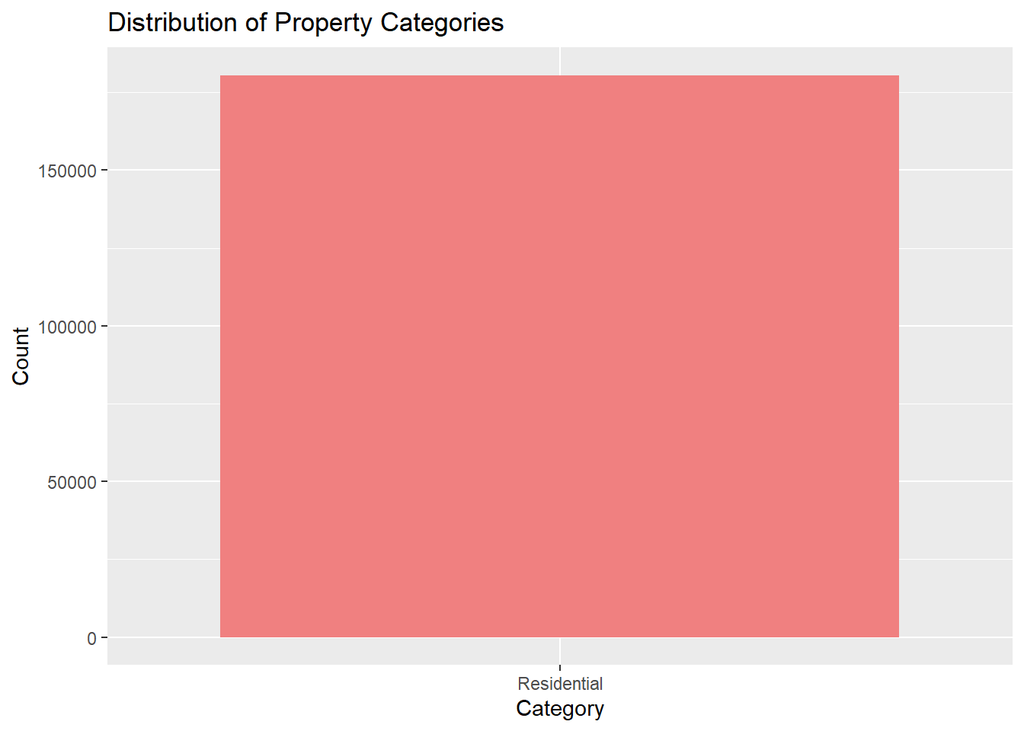

From the above chart, it appears that only residential is the category involved in the dataset. this is because the the data consider for the study are mostly urban areas.

```
## # A tibble: 21 × 3
##    NUMBER_BED     n Percentage
##         <dbl> <int>      <dbl>
##  1          0 15261       8.45
##  2          1 54194      30.0
##  3          2 67009      37.1
##  4          3 27442      15.2
##  5          4 11073       6.13
##  6          5  4245       2.35
##  7          6   930       0.52
##  8          7   226       0.13
##  9          8    65       0.04
## 10          9    21       0.01
## # ℹ 11 more rows
```

```
## # A tibble: 24 × 3
##    NUM_FLOORS      n Percentage
##         <dbl>  <int>      <dbl>
##  1          0 167096      92.6
##  2          1   8097       4.49
##  3          2   3200       1.77
##  4          3   1595       0.88
##  5          4    320       0.18
##  6          5     88       0.05
##  7          6     35       0.02
##  8          7     19       0.01
##  9          8     20       0.01
## 10          9      8       0
## # ℹ 14 more rows
```

```
## # A tibble: 16 × 3
##    NUM_BATHRO     n Percentage
##         <dbl> <int>      <dbl>
##  1          0 40973      22.7
##  2          1 94568      52.4
##  3          2 37309      20.7
##  4          3  5598       3.1
##  5          4  1463       0.81
##  6          5   424       0.23
##  7          6    95       0.05
##  8          7    47       0.03
##  9          8    22       0.01
## 10          9    10       0.01
## 11         10     2       0
## 12         11     4       0
## 13         12     4       0
## 14         16     1       0
## 15         22     1       0
## 16         29     1       0
```

```
## # A tibble: 11 × 3
##    NUM_RECEPT      n Percentage
##         <dbl>  <int>      <dbl>
##  1          0  60773      33.7
##  2          1 109977      60.9
##  3          2   8317       4.61
##  4          3   1146       0.63
##  5          4    221       0.12
##  6          5     70       0.04
##  7          6     14       0.01
##  8          7      2       0
##  9          9      1       0
## 10         12      1       0
## 11         29      1       0
```

From the summary above,the most common configuration is one reception room with (61%), followed by properties with zero receptions (34%) and two receptions (5%). Properties with higher numbers of reception rooms (4 or more) are relatively rare in the dataset, comprising less than 1% each.

Understanding the distribution of bathrooms in properties is crucial for homebuyers, renters, and real estate professionals as it directly impacts the property’s

functionality, value, and appeal to potential occupants.in the summary above,the most common configuration is one bathroom accounting for 52.39% of the entire data,

also,the vast majority of properties have zero floors, likely indicating single-story structures or apartments where floors are not counted individually Properties with

multiple floors (1-4 floors) are present but constitute a smaller proportion of the dataset. while properties with more than four floors are relatively rare, each

accounting for less than 0.2% of the dataset. as for the number of Beds, One and two-bedroom properties make up a significant portion of the dataset, catering to

singles, couples, and smaller families. 3 and 4-bedroom properties are also prevalent, meeting the needs of medium-sized families.

Properties with five or more bedrooms are less common but still present, catering to larger families or individuals seeking spacious living arrangements.

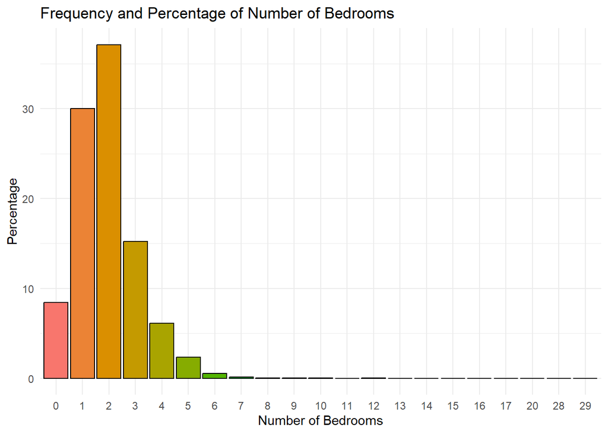

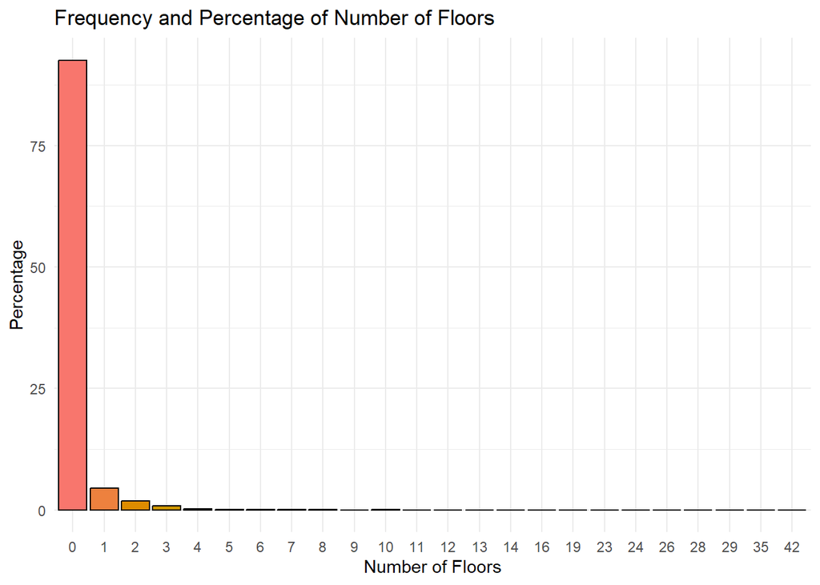

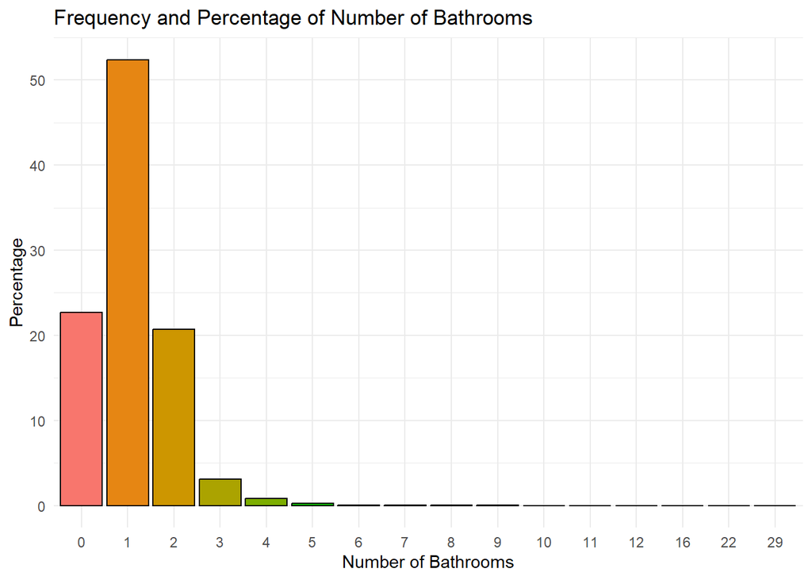

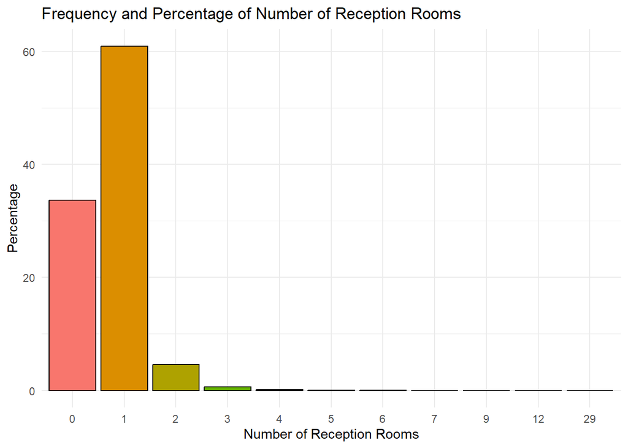

```
## # A tibble: 18 × 3
##    PROPERTY_T                  n Percentage
##    <chr>                   <int>      <dbl>
##  1 Barn conversion            33       0.02
##  2 Bungalow                  104       0.06
##  3 Cottage                   279       0.15
##  4 Country house               2       0
##  5 Detached bungalow          17       0.01
##  6 Detached house           1986       1.1
##  7 End terrace house        1665       0.92
##  8 Flat                   137339      76.1
##  9 Link-detached house        33       0.02
## 10 Lodge                       1       0
## 11 Maisonette               5285       2.93
## 12 Mews house                863       0.48
## 13 Semi-detached bungalow     35       0.02
## 14 Semi-detached house      3725       2.06
## 15 Studio                  15550       8.61
## 16 Terraced bungalow           7       0
## 17 Terraced house          11945       6.62
## 18 Town house               1654       0.92
```

```
## # A tibble: 2 × 3
##   LISTING_ST      n Percentage
##   <chr>       <int>      <dbl>
## 1 rent       139024       77.0
## 2 sale        41499       23.0
```

```
## # A tibble: 6 × 3
##   STATUS               n Percentage
##   <chr>            <int>      <dbl>
## 1 for_sale         27166      15.0
## 2 rent_under_offer 18940      10.5
## 3 rented           22071      12.2
## 4 sale_under_offer  3741       2.07
## 5 sold             10592       5.87
## 6 to_rent          98013      54.3
```

Key insights from the first summary (PROPERTY TYPE): Flats (apartments) constitute the majority (76.08%) of properties in the dataset, reflecting urban living preferences and high-density housing. Other common property types include detached houses, terraced houses(6.62%), studios (8.61%), and maisonettes, catering to different housing preferences and lifestyles. Less common property types such as barn conversions, lodges, and country houses represent niche markets or unique property styles.

Key insights from the second summary (LISTING STATUS):

Rent Listings has 139,024 listings (77.01%) categorized as “rent,” indicating properties available for rent while for Sale Listings, There are 41,499 listings (22.99%) categorized as “sale,” indicating properties available for sale.

Key insights from the third summary (STATUS OF THE PROPERTY):

The majority of listings are for properties available to rent, with a significant percentage categorized as “to_rent.” a notable percentage of properties categorized as “for_sale,” “rent_under_offer,” “rented,” “sale_under_offer,” and “sold,” reflecting various stages in the real estate market such as listings, pending offers, rented properties, and completed sales.

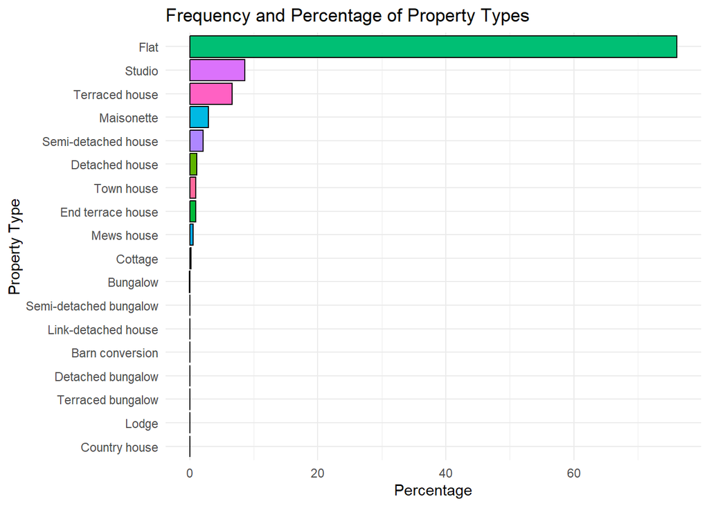

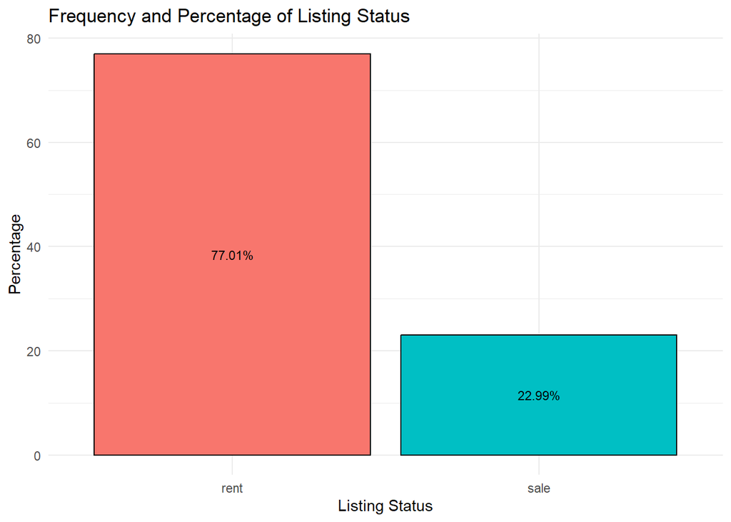

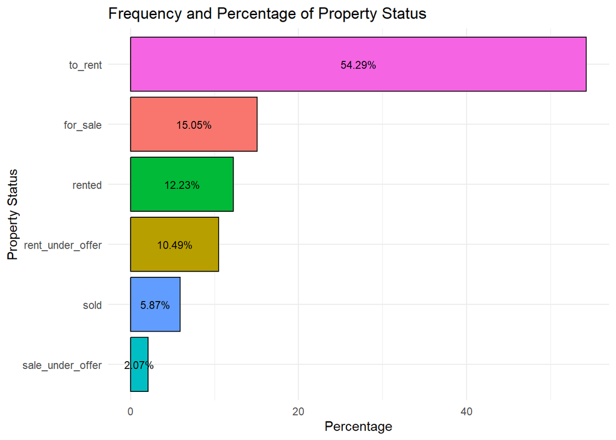

[output not shown]

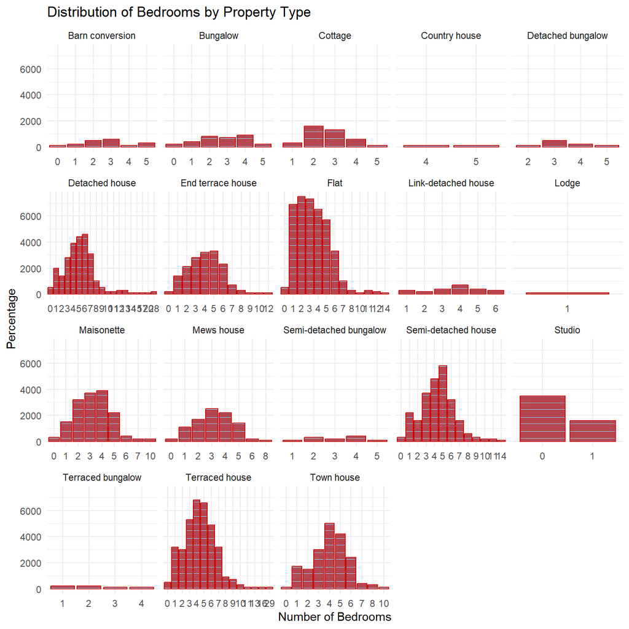

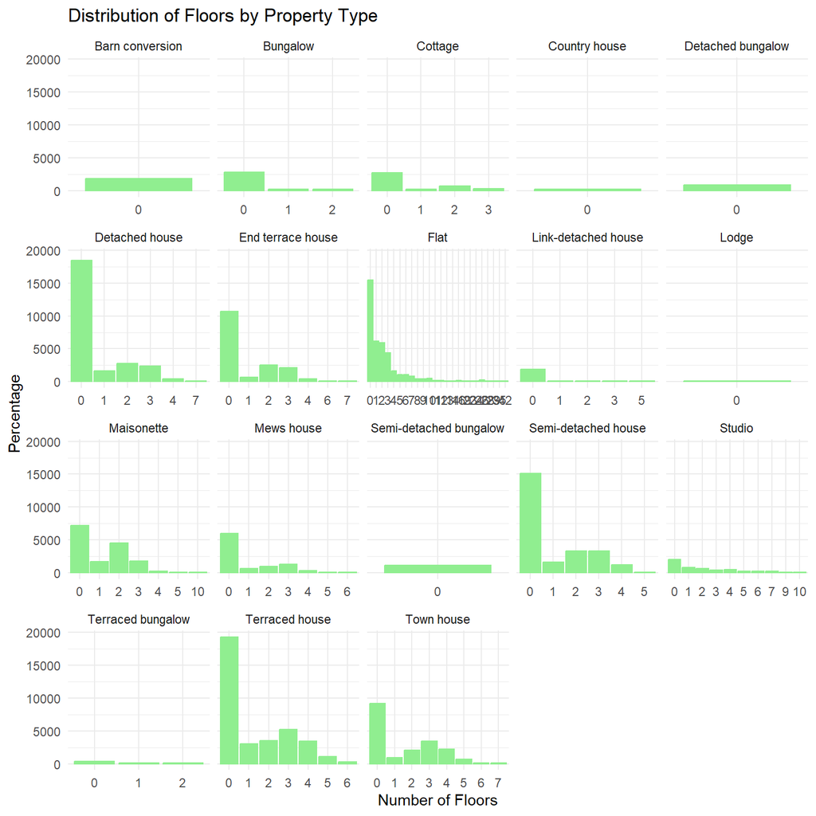

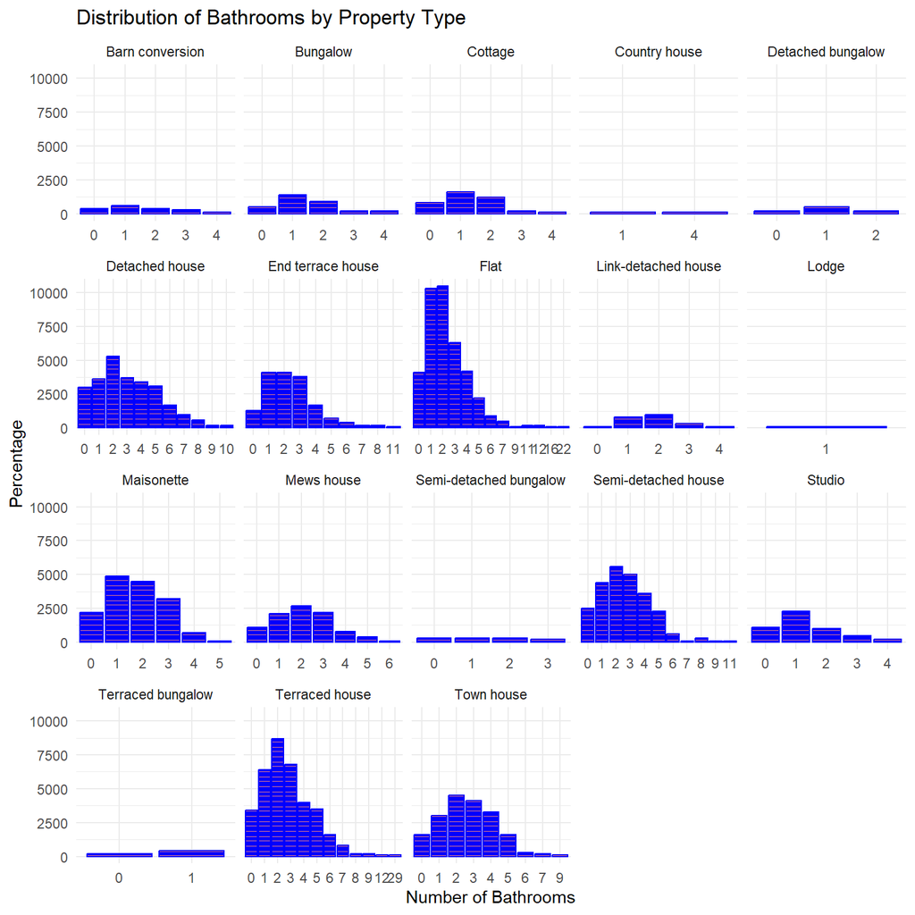

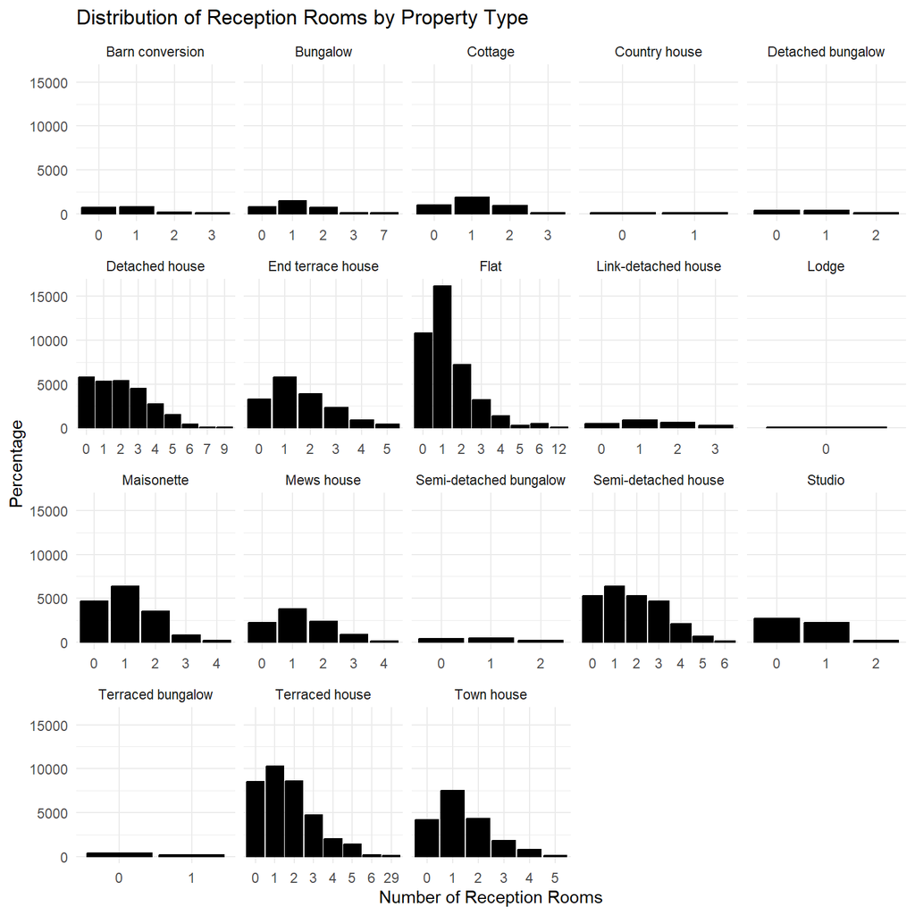

Let explore relationships between variables using bivariate analysis techniques like scatter plots for numerical variables and box plots for categorical variables against the PRICE variabl which is our main dependent variable

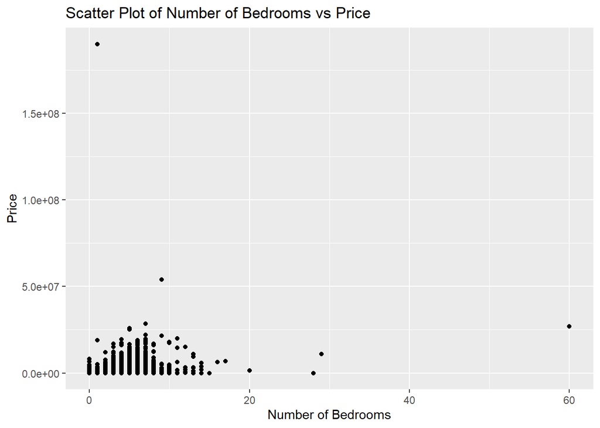

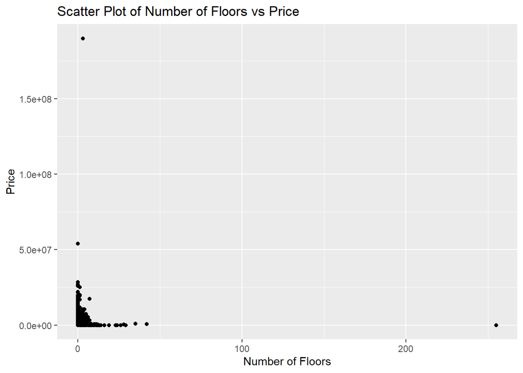

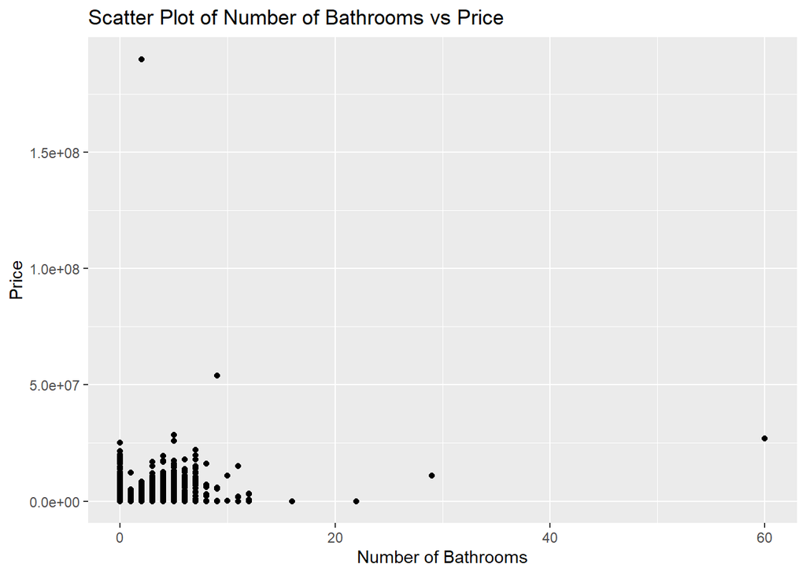

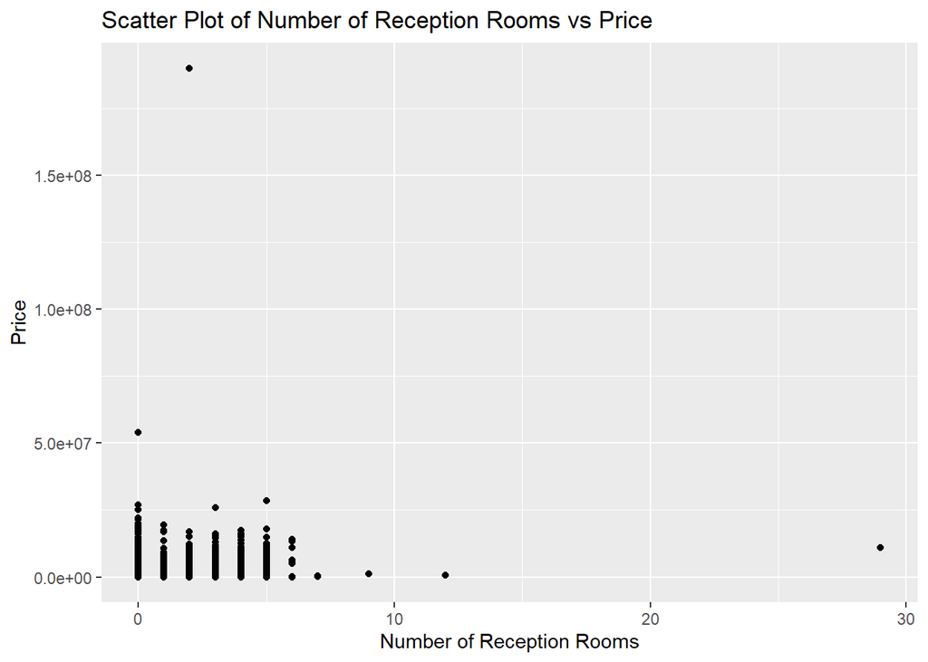

Load the Dataset: I Started by loading the dataset containing the Price variable and other relevant variables for analysis into R.

Log Transformation: I then Use the logarithm transformation function in R to transform the Price variable. In R, the log() function can be applied directly to the Price column or as part of a data transformation pipeline. but since i neded the log transofrm the price alone, i did a price colum transformation.

Visualization: After log transformation,I then created scatter plots as seen below with the transformed Price variable and other selected variables of interest in oder to compare the plots with the original data to observe changes in relationships and data spread.

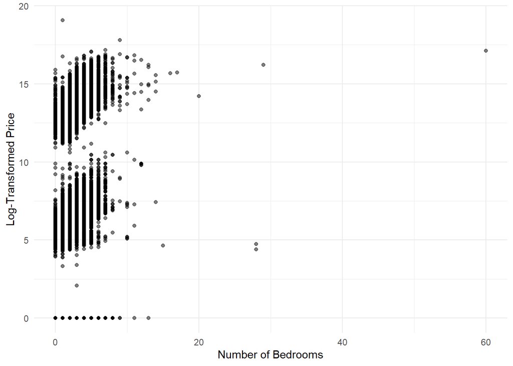

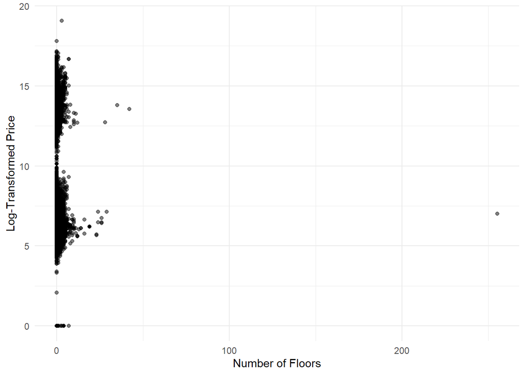

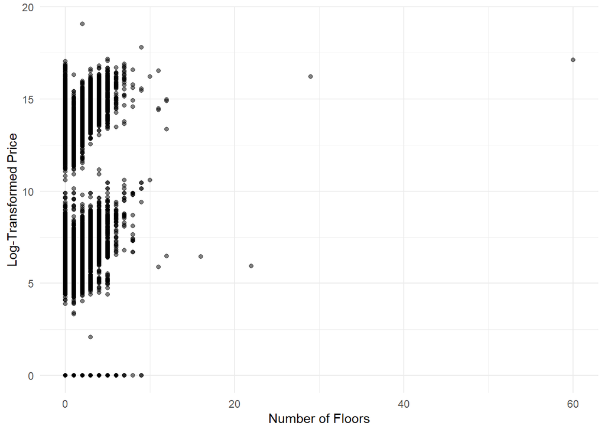

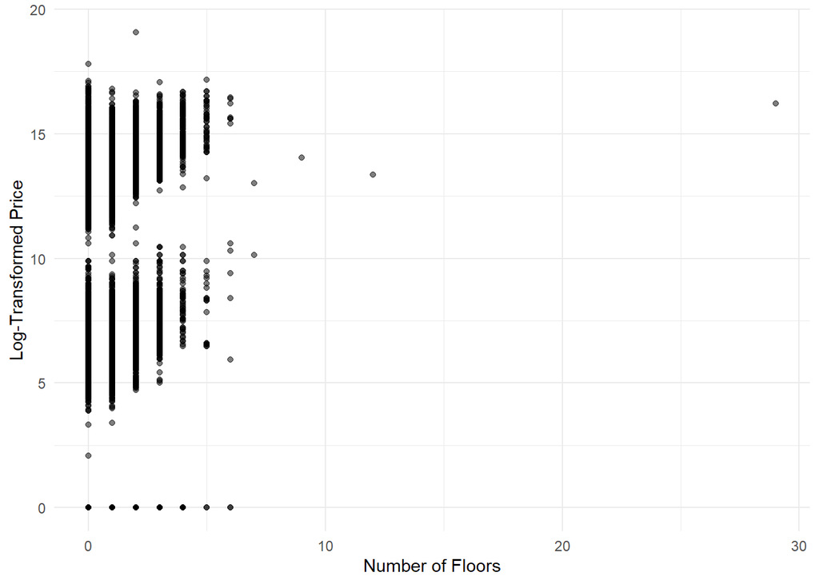

# Explaining the scatter plot above

the first scatter plot illustrates the relationship between the log-transformed price of properties and the number of bedrooms they have. It shows how prices vary across different property sizes.The black data points are scattered across the graph.Most data points cluster between approximately 0 and 20 bedrooms suggesting that most properties listed have a varying log-transformed price within this range

Also number the distribution of number of floor are displayed on the scatter plot. majority of the house are cluster between 0 and 10

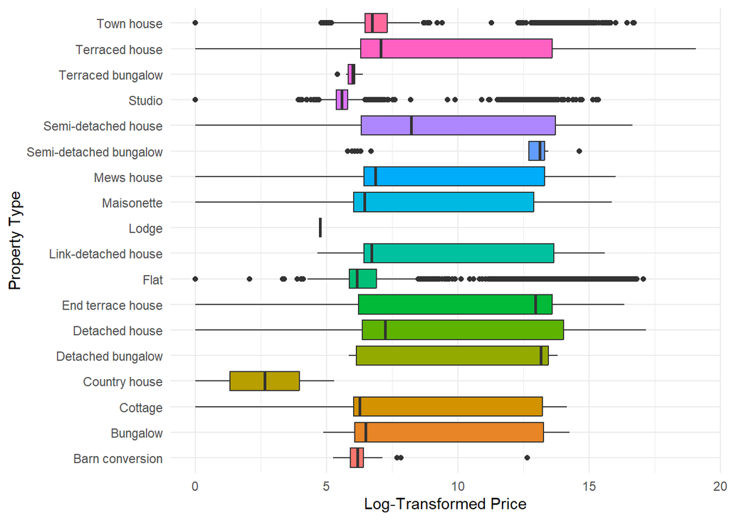

the figure above shows the box plot of the price across the property type. although majority of the properties indicates that there is outliers this is due to the fact that the data considered for this study includes rent and sales properties

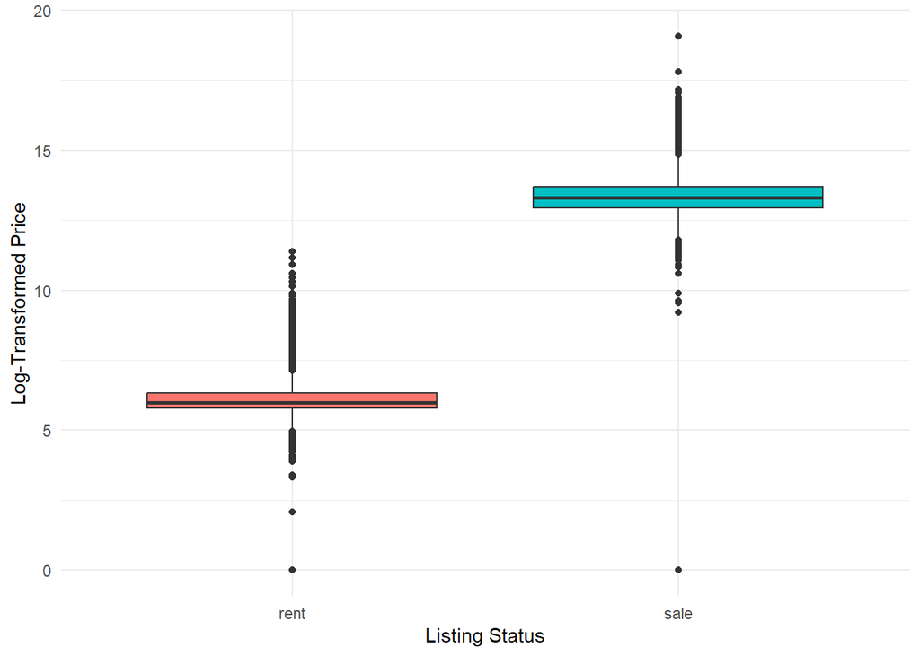

```r
# Box plot for LISTING_ST against log-transformed PRICE
ggplot(property_database_final, aes(x = LISTING_ST, y = PRICE_log, fill = LISTING_ST)) +
  geom_boxplot() +
  labs(x = "Listing Status", y = "Log-Transformed Price") +
  theme_minimal() +
  scale_fill_discrete(name = "Listing Status") +
  theme(legend.position = "none")
```

[figure not shown]

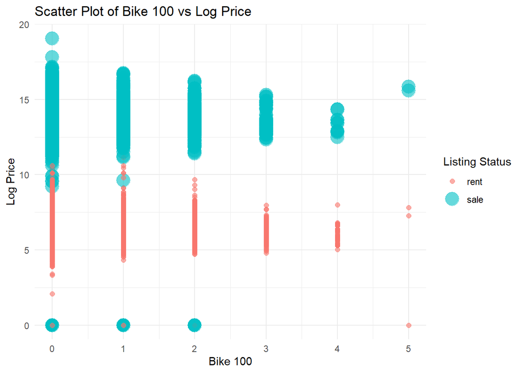

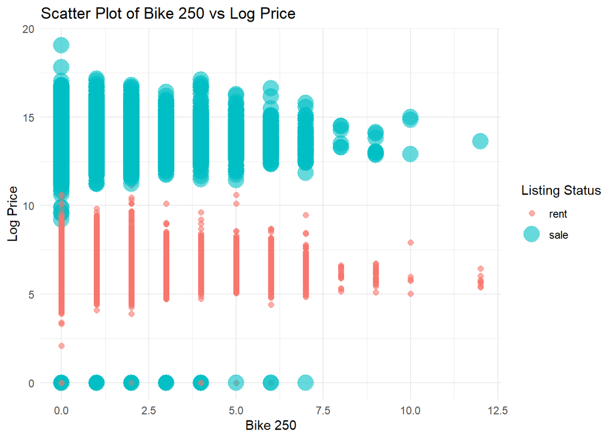

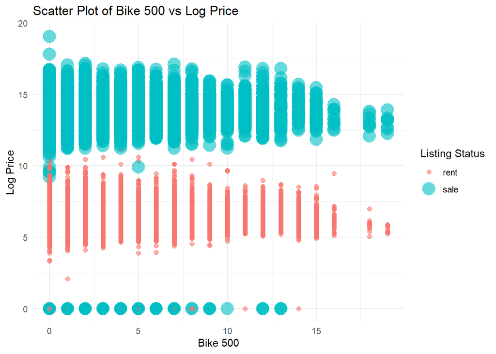

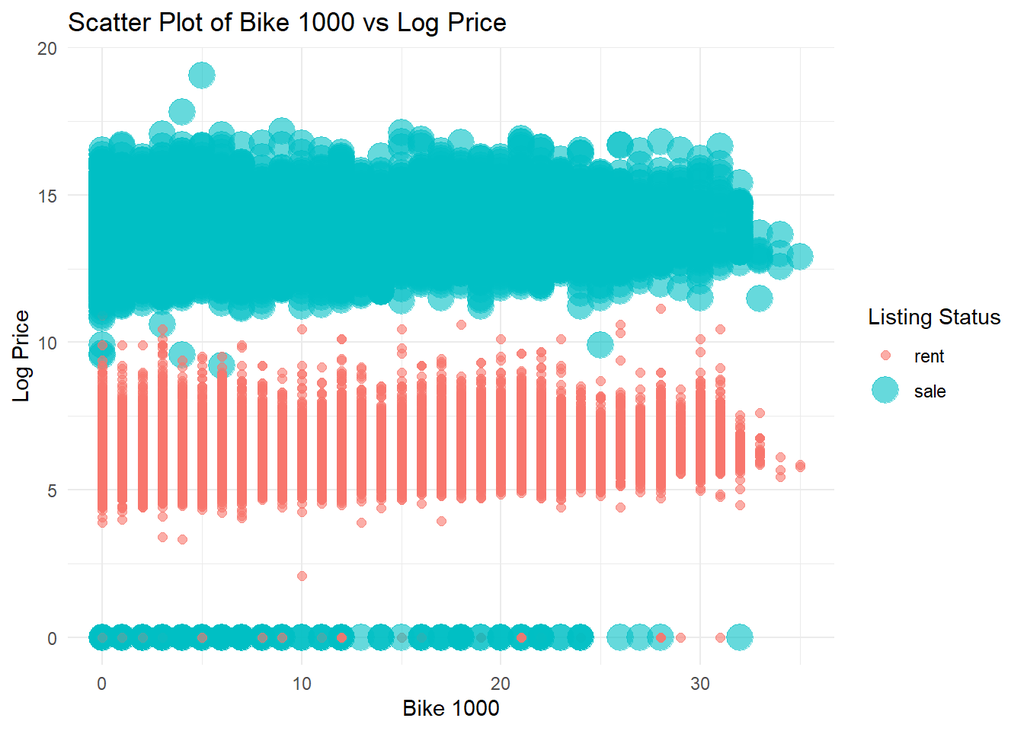

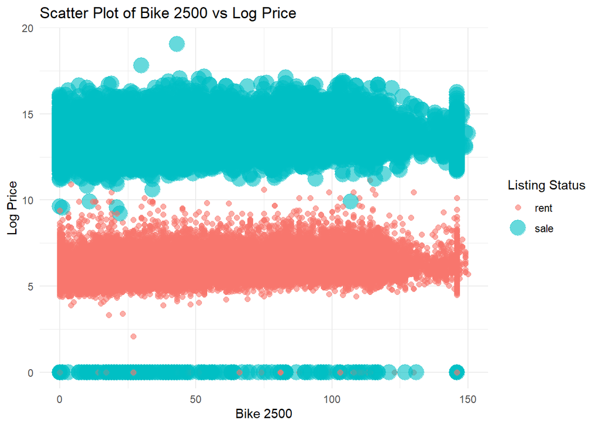

```r
# Box plot for STATUS against log-transformed PRICE
ggplot(property_database_final, aes(x = factor(STATUS), y = PRICE_log, fill = STATUS)) +
  geom_boxplot() +
 labs(x = "Listing Status", y = "Log-Transformed Price") +
   theme_minimal() +
  scale_fill_discrete(name = "Status") +
  theme(legend.position = "none")
```

[output not shown]

Interpretation: The graph displays the relationship between two variables “Bike 100”,“Bike 250”,“Bike 500”,“Bike 1000”,“Bike 2500” and “Log Price.” this suggests that as the value of each bike at different distances increases, the log price remains relatively constant for both rental and sale listings. Also, the distinct clusters of data points indicate different pricing behaviors for rentals and sales.

```r
library(dplyr)

# Calculate the sum of PRICE against LISTING_ST
sum_price_listing <- property_database_final %>%
  group_by(LISTING_ST) %>%
  summarise(Sum_Price = sum(PRICE, na.rm = TRUE))

# View the resulting data
print(sum_price_listing)
```

```
## # A tibble: 2 × 2
##   LISTING_ST   Sum_Price
##   <chr>            <dbl>
## 1 rent          71340906
## 2 sale       36206278032
```